# udacity_project2

```python
import pandas as pd
import numpy as np
import json
import requests
import matplotlib.pyplot as plt
import seaborn as sns
%matplotlib inline
```

```python
#loading the first dataset
dfArchive = pd.read_csv('C:/Users/HP/Downloads/twitter-archive-enhanced.csv')
```

```python
#inspecting the data
dfArchive.head()
```

|  | tweet_id | in_reply_to_status_id | in_reply_to_user_id | timestamp | source | text | retweeted_status_id | retweeted_status_user_id | retweeted_status_timestamp | expanded_urls | rating_numerator | rating_denominator | name | doggo | floofer | pupper | puppo |
| --- | --- | --- | --- | --- | --- | --- | --- | --- | --- | --- | --- | --- | --- | --- | --- | --- | --- |
| 0 | 892420643555336193 | NaN | NaN | 2017-08-01 16:23:56 +0000 | <a href="http://twitter.com/download/iphone" r... | This is Phineas. He's a mystical boy. Only eve... | NaN | NaN | NaN | https://twitter.com/dog_rates/status/892420643... | 13 | 10 | Phineas | None | None | None | None |
| 1 | 892177421306343426 | NaN | NaN | 2017-08-01 00:17:27 +0000 | <a href="http://twitter.com/download/iphone" r... | This is Tilly. She's just checking pup on you.... | NaN | NaN | NaN | https://twitter.com/dog_rates/status/892177421... | 13 | 10 | Tilly | None | None | None | None |
| 2 | 891815181378084864 | NaN | NaN | 2017-07-31 00:18:03 +0000 | <a href="http://twitter.com/download/iphone" r... | This is Archie. He is a rare Norwegian Pouncin... | NaN | NaN | NaN | https://twitter.com/dog_rates/status/891815181... | 12 | 10 | Archie | None | None | None | None |
| 3 | 891689557279858688 | NaN | NaN | 2017-07-30 15:58:51 +0000 | <a href="http://twitter.com/download/iphone" r... | This is Darla. She commenced a snooze mid meal... | NaN | NaN | NaN | https://twitter.com/dog_rates/status/891689557... | 13 | 10 | Darla | None | None | None | None |
| 4 | 891327558926688256 | NaN | NaN | 2017-07-29 16:00:24 +0000 | <a href="http://twitter.com/download/iphone" r... | This is Franklin. He would like you to stop ca... | NaN | NaN | NaN | https://twitter.com/dog_rates/status/891327558... | 12 | 10 | Franklin | None | None | None | None |

```python
#loading the image dataset
url = ' https://d17h27t6h515a5.cloudfront.net/topher/2017/August/599fd2ad_image-predictions/image-predictions.tsv'
response = requests.get(url)

# Save HTML to file

with open("image-predictions.tsv", mode='wb') as file:
    file.write(response.content)
```

```python
dfImage = pd.read_csv('image-predictions.tsv', sep='\t')
```

```python
#inspecting the image dataset
dfImage.head()
```

|  | tweet_id | jpg_url | img_num | p1 | p1_conf | p1_dog | p2 | p2_conf | p2_dog | p3 | p3_conf | p3_dog |
| --- | --- | --- | --- | --- | --- | --- | --- | --- | --- | --- | --- | --- |
| 0 | 666020888022790149 | https://pbs.twimg.com/media/CT4udn0WwAA0aMy.jpg | 1 | Welsh_springer_spaniel | 0.465074 | True | collie | 0.156665 | True | Shetland_sheepdog | 0.061428 | True |
| 1 | 666029285002620928 | https://pbs.twimg.com/media/CT42GRgUYAA5iDo.jpg | 1 | redbone | 0.506826 | True | miniature_pinscher | 0.074192 | True | Rhodesian_ridgeback | 0.072010 | True |
| 2 | 666033412701032449 | https://pbs.twimg.com/media/CT4521TWwAEvMyu.jpg | 1 | German_shepherd | 0.596461 | True | malinois | 0.138584 | True | bloodhound | 0.116197 | True |
| 3 | 666044226329800704 | https://pbs.twimg.com/media/CT5Dr8HUEAA-lEu.jpg | 1 | Rhodesian_ridgeback | 0.408143 | True | redbone | 0.360687 | True | miniature_pinscher | 0.222752 | True |
| 4 | 666049248165822465 | https://pbs.twimg.com/media/CT5IQmsXIAAKY4A.jpg | 1 | miniature_pinscher | 0.560311 | True | Rottweiler | 0.243682 | True | Doberman | 0.154629 | True |

```python
#loading the tweets dataset
tweets = []

with open('C:/Users/HP/Downloads/tweet-json.txt', 'r') as file:
    for line in file:
        data = json.loads(line)
        tweets.append(data)
```

```python
dfTweets = pd.DataFrame(tweets)
```

```python
#inspecting the twweets dataset
dfTweets.head()
```

|  | created_at | id | id_str | full_text | truncated | display_text_range | entities | extended_entities | source | in_reply_to_status_id | ... | favorite_count | favorited | retweeted | possibly_sensitive | possibly_sensitive_appealable | lang | retweeted_status | quoted_status_id | quoted_status_id_str | quoted_status |
| --- | --- | --- | --- | --- | --- | --- | --- | --- | --- | --- | --- | --- | --- | --- | --- | --- | --- | --- | --- | --- | --- |
| 0 | Tue Aug 01 16:23:56 +0000 2017 | 892420643555336193 | 892420643555336193 | This is Phineas. He's a mystical boy. Only eve... | False | [0, 85] | {'hashtags': [], 'symbols': [], 'user_mentions... | {'media': [{'id': 892420639486877696, 'id_str'... | <a href="http://twitter.com/download/iphone" r... | NaN | ... | 39467 | False | False | False | False | en | NaN | NaN | NaN | NaN |
| 1 | Tue Aug 01 00:17:27 +0000 2017 | 892177421306343426 | 892177421306343426 | This is Tilly. She's just checking pup on you.... | False | [0, 138] | {'hashtags': [], 'symbols': [], 'user_mentions... | {'media': [{'id': 892177413194625024, 'id_str'... | <a href="http://twitter.com/download/iphone" r... | NaN | ... | 33819 | False | False | False | False | en | NaN | NaN | NaN | NaN |
| 2 | Mon Jul 31 00:18:03 +0000 2017 | 891815181378084864 | 891815181378084864 | This is Archie. He is a rare Norwegian Pouncin... | False | [0, 121] | {'hashtags': [], 'symbols': [], 'user_mentions... | {'media': [{'id': 891815175371796480, 'id_str'... | <a href="http://twitter.com/download/iphone" r... | NaN | ... | 25461 | False | False | False | False | en | NaN | NaN | NaN | NaN |
| 3 | Sun Jul 30 15:58:51 +0000 2017 | 891689557279858688 | 891689557279858688 | This is Darla. She commenced a snooze mid meal... | False | [0, 79] | {'hashtags': [], 'symbols': [], 'user_mentions... | {'media': [{'id': 891689552724799489, 'id_str'... | <a href="http://twitter.com/download/iphone" r... | NaN | ... | 42908 | False | False | False | False | en | NaN | NaN | NaN | NaN |
| 4 | Sat Jul 29 16:00:24 +0000 2017 | 891327558926688256 | 891327558926688256 | This is Franklin. He would like you to stop ca... | False | [0, 138] | {'hashtags': [{'text': 'BarkWeek', 'indices': ... | {'media': [{'id': 891327551943041024, 'id_str'... | <a href="http://twitter.com/download/iphone" r... | NaN | ... | 41048 | False | False | False | False | en | NaN | NaN | NaN | NaN |

5 rows × 31 columns

```python
#subsetting it to the number of columns needed
dfTweets = dfTweets[['id', 'retweet_count', 'favorite_count']]
```

```python
dfTweets.head()
```

|  | id | retweet_count | favorite_count |
| --- | --- | --- | --- |
| 0 | 892420643555336193 | 8853 | 39467 |
| 1 | 892177421306343426 | 6514 | 33819 |
| 2 | 891815181378084864 | 4328 | 25461 |
| 3 | 891689557279858688 | 8964 | 42908 |
| 4 | 891327558926688256 | 9774 | 41048 |

## Assessing the data

```python
#assessing visually
dfArchive.sample(10)
```

|  | tweet_id | in_reply_to_status_id | in_reply_to_user_id | timestamp | source | text | retweeted_status_id | retweeted_status_user_id | retweeted_status_timestamp | expanded_urls | rating_numerator | rating_denominator | name | doggo | floofer | pupper | puppo |
| --- | --- | --- | --- | --- | --- | --- | --- | --- | --- | --- | --- | --- | --- | --- | --- | --- | --- |
| 2114 | 670433248821026816 | NaN | NaN | 2015-11-28 02:45:17 +0000 | <a href="http://twitter.com/download/iphone" r... | This is Sam. He's trying to escape the inordin... | NaN | NaN | NaN | https://twitter.com/dog_rates/status/670433248... | 10 | 10 | Sam | None | None | None | None |
| 789 | 773985732834758656 | NaN | NaN | 2016-09-08 20:45:53 +0000 | <a href="http://twitter.com/download/iphone" r... | Meet Winnie. She just made awkward eye contact... | NaN | NaN | NaN | https://twitter.com/dog_rates/status/773985732... | 11 | 10 | Winnie | None | None | pupper | None |
| 217 | 850380195714523136 | NaN | NaN | 2017-04-07 16:10:12 +0000 | <a href="http://twitter.com/download/iphone" r... | This is Leo. He's a personal triathlon coach. ... | NaN | NaN | NaN | https://twitter.com/dog_rates/status/850380195... | 13 | 10 | Leo | None | None | None | None |
| 1222 | 714258258790387713 | NaN | NaN | 2016-03-28 01:10:13 +0000 | <a href="http://twitter.com/download/iphone" r... | Meet Travis and Flurp. Travis is pretty chill ... | NaN | NaN | NaN | https://twitter.com/dog_rates/status/714258258... | 10 | 10 | Travis | None | None | None | None |
| 797 | 773191612633579521 | NaN | NaN | 2016-09-06 16:10:20 +0000 | <a href="http://twitter.com/download/iphone" r... | This is Grey. He's the dogtor in charge of you... | NaN | NaN | NaN | https://twitter.com/dog_rates/status/773191612... | 12 | 10 | Grey | None | None | None | None |
| 1113 | 733109485275860992 | NaN | NaN | 2016-05-19 01:38:16 +0000 | <a href="http://twitter.com/download/iphone" r... | Like father (doggo), like son (pupper). Both 1... | NaN | NaN | NaN | https://twitter.com/dog_rates/status/733109485... | 12 | 10 | None | doggo | None | pupper | None |
| 1475 | 693642232151285760 | NaN | NaN | 2016-01-31 03:49:30 +0000 | <a href="http://twitter.com/download/iphone" r... | Meet Freddery. He's a Westminster Toblerone. S... | NaN | NaN | NaN | https://twitter.com/dog_rates/status/693642232... | 9 | 10 | Freddery | None | None | None | None |
| 1855 | 675531475945709568 | NaN | NaN | 2015-12-12 04:23:49 +0000 | <a href="http://twitter.com/download/iphone" r... | This is Ellie AKA Queen Slayer of the Orbs. Ve... | NaN | NaN | NaN | https://twitter.com/dog_rates/status/675531475... | 10 | 10 | Ellie | None | None | None | None |
| 2269 | 667509364010450944 | NaN | NaN | 2015-11-20 01:06:48 +0000 | <a href="http://twitter.com" rel="nofollow">Tw... | This a Norwegian Pewterschmidt named Tickles. ... | NaN | NaN | NaN | https://twitter.com/dog_rates/status/667509364... | 12 | 10 | None | None | None | None | None |
| 677 | 789280767834746880 | NaN | NaN | 2016-10-21 01:42:53 +0000 | <a href="http://twitter.com/download/iphone" r... | RT @dog_rates: This is Meyer. He has to hold s... | 7.507196e+17 | 4.196984e+09 | 2016-07-06 15:54:42 +0000 | https://twitter.com/dog_rates/status/750719632... | 12 | 10 | Meyer | None | None | None | None |

```python
#assessing programmatically
dfArchive.info()
```

```
<class 'pandas.core.frame.DataFrame'>
RangeIndex: 2356 entries, 0 to 2355
Data columns (total 17 columns):
 #   Column                      Non-Null Count  Dtype
---  ------                      --------------  -----
 0   tweet_id                    2356 non-null   int64
 1   in_reply_to_status_id       78 non-null     float64
 2   in_reply_to_user_id         78 non-null     float64
 3   timestamp                   2356 non-null   object
 4   source                      2356 non-null   object
 5   text                        2356 non-null   object
 6   retweeted_status_id         181 non-null    float64
 7   retweeted_status_user_id    181 non-null    float64
 8   retweeted_status_timestamp  181 non-null    object
 9   expanded_urls               2297 non-null   object
 10  rating_numerator            2356 non-null   int64
 11  rating_denominator          2356 non-null   int64
 12  name                        2356 non-null   object
 13  doggo                       2356 non-null   object
 14  floofer                     2356 non-null   object
 15  pupper                      2356 non-null   object
 16  puppo                       2356 non-null   object
dtypes: float64(4), int64(3), object(10)
memory usage: 313.0+ KB
```

```python
#assessing visually
dfImage.sample(10)
```

|  | tweet_id | jpg_url | img_num | p1 | p1_conf | p1_dog | p2 | p2_conf | p2_dog | p3 | p3_conf | p3_dog |
| --- | --- | --- | --- | --- | --- | --- | --- | --- | --- | --- | --- | --- |
| 2044 | 886258384151887873 | https://pbs.twimg.com/media/DEyfTG4UMAE4aE9.jpg | 1 | pug | 0.943575 | True | shower_cap | 0.025286 | False | Siamese_cat | 0.002849 | False |
| 165 | 668979806671884288 | https://pbs.twimg.com/media/CUixld6WoAArDrJ.jpg | 1 | golden_retriever | 0.608537 | True | Irish_setter | 0.097078 | True | redbone | 0.076022 | True |
| 312 | 671547767500775424 | https://pbs.twimg.com/media/CVHRIiqWEAAj98K.jpg | 2 | Loafer | 0.255088 | False | platypus | 0.090019 | False | cowboy_boot | 0.066536 | False |
| 1096 | 720059472081784833 | https://pbs.twimg.com/media/Cf4qRcmWEAA9V4h.jpg | 1 | Mexican_hairless | 0.451852 | True | redbone | 0.254884 | True | Italian_greyhound | 0.094818 | True |
| 1647 | 808733504066486276 | https://pbs.twimg.com/media/Czky0v9VIAEXRkd.jpg | 1 | seat_belt | 0.779137 | False | toy_poodle | 0.036927 | True | golden_retriever | 0.016972 | True |
| 1882 | 847157206088847362 | https://pbs.twimg.com/media/C8G0_CMWsAAjjAY.jpg | 2 | Staffordshire_bullterrier | 0.219609 | True | American_Staffordshire_terrier | 0.178671 | True | pug | 0.123271 | True |
| 633 | 680970795137544192 | https://pbs.twimg.com/media/CXNLU6wWkAE0OkJ.jpg | 1 | pug | 0.713102 | True | whippet | 0.057426 | True | quilt | 0.056018 | False |
| 1767 | 826958653328592898 | https://pbs.twimg.com/media/C3nygbBWQAAjwcW.jpg | 1 | golden_retriever | 0.617389 | True | Labrador_retriever | 0.337053 | True | tennis_ball | 0.008554 | False |
| 394 | 673612854080196609 | https://pbs.twimg.com/media/CVknUTlVEAARjU5.jpg | 1 | Newfoundland | 0.223101 | True | Leonberg | 0.111106 | True | shovel | 0.085626 | False |
| 406 | 673708611235921920 | https://pbs.twimg.com/media/CVl-Z0dWcAAs7wr.jpg | 1 | golden_retriever | 0.936333 | True | cocker_spaniel | 0.024211 | True | Labrador_retriever | 0.009435 | True |

```python
#assessing programatically
dfImage.info()
```

```
<class 'pandas.core.frame.DataFrame'>
RangeIndex: 2075 entries, 0 to 2074
Data columns (total 12 columns):
 #   Column    Non-Null Count  Dtype
---  ------    --------------  -----
 0   tweet_id  2075 non-null   int64
 1   jpg_url   2075 non-null   object
 2   img_num   2075 non-null   int64
 3   p1        2075 non-null   object
 4   p1_conf   2075 non-null   float64
 5   p1_dog    2075 non-null   bool
 6   p2        2075 non-null   object
 7   p2_conf   2075 non-null   float64
 8   p2_dog    2075 non-null   bool
 9   p3        2075 non-null   object
 10  p3_conf   2075 non-null   float64
 11  p3_dog    2075 non-null   bool
dtypes: bool(3), float64(3), int64(2), object(4)
memory usage: 152.1+ KB
```

```python
#assessing visually
dfTweets.sample(10)
```

|  | id | retweet_count | favorite_count |
| --- | --- | --- | --- |
| 916 | 756651752796094464 | 1511 | 5612 |
| 2285 | 667177989038297088 | 58 | 200 |
| 1968 | 673295268553605120 | 3484 | 8046 |
| 231 | 847962785489326080 | 5730 | 25296 |
| 692 | 786963064373534720 | 9327 | 29725 |
| 1676 | 682047327939461121 | 1088 | 3525 |
| 1896 | 674690135443775488 | 510 | 1237 |
| 241 | 846153765933735936 | 10226 | 34394 |
| 2143 | 669926384437997569 | 115 | 400 |
| 1595 | 686050296934563840 | 836 | 2420 |

```python
#assessing programmatically
dfTweets.info()
```

```
<class 'pandas.core.frame.DataFrame'>
RangeIndex: 2354 entries, 0 to 2353
Data columns (total 3 columns):
 #   Column          Non-Null Count  Dtype
---  ------          --------------  -----
 0   id              2354 non-null   int64
 1   retweet_count   2354 non-null   int64
 2   favorite_count  2354 non-null   int64
dtypes: int64(3)
memory usage: 55.3 KB
```

## Summary of Issues Detected

Quality Issues

Twitter Archive Dataset

Tweets Dataset

1. The id column was renamed to tweet_id to match with tweeter archive dataset

Tidiness Issues

Twitter Archive Dataset

1. The doggo, floofer, pupper, and puppo columns were combined into one

Image Dataset

1. The p1, p1_conf, p1_dog, p2, p2_conf, p2_dog, p3, p3_conf, and p3_dog columns were all combined into two columns breeds and confidence
2. The p1, p1_conf, p1_dog, p2, p2_conf, p2_dog, p3, p3_conf, and p3_dog columns were all dropped
3. All the 3 datasets were merged using join

## Data Cleaning

```python
dfArcClean = dfArchive.copy()
dfImgClean = dfImage.copy()
dfTwClean = dfTweets.copy()
```

```python
#to check for missing values
dfArchive.isna().sum()
```

```
tweet_id                         0
in_reply_to_status_id         2278
in_reply_to_user_id           2278
timestamp                        0
source                           0
text                             0
retweeted_status_id           2175
retweeted_status_user_id      2175
retweeted_status_timestamp    2175
expanded_urls                   59
rating_numerator                 0
rating_denominator               0
name                             0
doggo                            0
floofer                          0
pupper                           0
puppo                            0
dtype: int64
```

issue 1- The following columns are replies, had a lot of missing values and not needed in the analysis. So, they were dropped a. in_reply_to_status_id b. in_reply_to_user_id

```python
#code
#drop function was defined
def mydrop(dataframe, col_row, axis=1):
    dataframe.drop(col_row, axis = axis, inplace = True)
```

```python
#to get the index of rows to drop
reply_status_idx = dfArcClean[dfArcClean['in_reply_to_status_id'].notnull()].index
```

```python
reply_status_idx
```

```
Int64Index([  30,   55,   64,  113,  148,  149,  179,  184,  186,  188,  189,
             218,  228,  234,  251,  274,  290,  291,  313,  342,  346,  387,
             409,  427,  498,  513,  565,  570,  576,  611,  701,  843,  857,
             967, 1005, 1016, 1018, 1080, 1127, 1295, 1330, 1339, 1345, 1356,
            1446, 1452, 1464, 1474, 1479, 1497, 1501, 1523, 1598, 1605, 1618,
            1630, 1634, 1663, 1689, 1774, 1819, 1842, 1844, 1852, 1866, 1882,
            1885, 1892, 1895, 1905, 1914, 1940, 2036, 2038, 2149, 2169, 2189,
            2298],
           dtype='int64')
```

```python
#rows are dropped first
mydrop(dfArcClean, reply_status_idx, axis = 0)
```

```python
#test

dfArcClean.info()
```

```
<class 'pandas.core.frame.DataFrame'>
Int64Index: 2278 entries, 0 to 2355
Data columns (total 17 columns):
 #   Column                      Non-Null Count  Dtype
---  ------                      --------------  -----
 0   tweet_id                    2278 non-null   int64
 1   in_reply_to_status_id       0 non-null      float64
 2   in_reply_to_user_id         0 non-null      float64
 3   timestamp                   2278 non-null   object
 4   source                      2278 non-null   object
 5   text                        2278 non-null   object
 6   retweeted_status_id         181 non-null    float64
 7   retweeted_status_user_id    181 non-null    float64
 8   retweeted_status_timestamp  181 non-null    object
 9   expanded_urls               2274 non-null   object
 10  rating_numerator            2278 non-null   int64
 11  rating_denominator          2278 non-null   int64
 12  name                        2278 non-null   object
 13  doggo                       2278 non-null   object
 14  floofer                     2278 non-null   object
 15  pupper                      2278 non-null   object
 16  puppo                       2278 non-null   object
dtypes: float64(4), int64(3), object(10)
memory usage: 320.3+ KB
```

```python
#code to drop the columns

columnsToDrop = ['in_reply_to_status_id', 'in_reply_to_user_id']
mydrop(dfArcClean, columnsToDrop, axis = 1)
```

```python
#test
dfArcClean.info()
```

```
<class 'pandas.core.frame.DataFrame'>
Int64Index: 2278 entries, 0 to 2355
Data columns (total 15 columns):
 #   Column                      Non-Null Count  Dtype
---  ------                      --------------  -----
 0   tweet_id                    2278 non-null   int64
 1   timestamp                   2278 non-null   object
 2   source                      2278 non-null   object
 3   text                        2278 non-null   object
 4   retweeted_status_id         181 non-null    float64
 5   retweeted_status_user_id    181 non-null    float64
 6   retweeted_status_timestamp  181 non-null    object
 7   expanded_urls               2274 non-null   object
 8   rating_numerator            2278 non-null   int64
 9   rating_denominator          2278 non-null   int64
 10  name                        2278 non-null   object
 11  doggo                       2278 non-null   object
 12  floofer                     2278 non-null   object
 13  pupper                      2278 non-null   object
 14  puppo                       2278 non-null   object
dtypes: float64(2), int64(3), object(10)
memory usage: 284.8+ KB
```

the reply columns have been dropped

issue 2- The timestamp column had a wrong data type and was converted to datetime datatype

```python
#code to change the data type of timestamp columns

dfArcClean['timestamp'] = pd.to_datetime(dfArcClean['timestamp'])
```

```python
#test
dfArcClean.info()
```

```
<class 'pandas.core.frame.DataFrame'>
Int64Index: 2278 entries, 0 to 2355
Data columns (total 15 columns):
 #   Column                      Non-Null Count  Dtype
---  ------                      --------------  -----
 0   tweet_id                    2278 non-null   int64
 1   timestamp                   2278 non-null   datetime64[ns, UTC]
 2   source                      2278 non-null   object
 3   text                        2278 non-null   object
 4   retweeted_status_id         181 non-null    float64
 5   retweeted_status_user_id    181 non-null    float64
 6   retweeted_status_timestamp  181 non-null    object
 7   expanded_urls               2274 non-null   object
 8   rating_numerator            2278 non-null   int64
 9   rating_denominator          2278 non-null   int64
 10  name                        2278 non-null   object
 11  doggo                       2278 non-null   object
 12  floofer                     2278 non-null   object
 13  pupper                      2278 non-null   object
 14  puppo                       2278 non-null   object
dtypes: datetime64[ns, UTC](1), float64(2), int64(3), object(9)
memory usage: 284.8+ KB
```

issue 3- 3. The source column had html tags that were not needed, the real sources were extracted

```python
#to really see the full column
pd.set_option('display.max_colwidth', 600)
```

```python
dfArcClean['source'].sample(20)
```

```
1575    <a href="http://twitter.com/download/iphone" rel="nofollow">Twitter for iPhone</a>
589     <a href="http://twitter.com/download/iphone" rel="nofollow">Twitter for iPhone</a>
2167    <a href="http://twitter.com/download/iphone" rel="nofollow">Twitter for iPhone</a>
1271    <a href="http://twitter.com/download/iphone" rel="nofollow">Twitter for iPhone</a>
2158    <a href="http://twitter.com/download/iphone" rel="nofollow">Twitter for iPhone</a>
1435    <a href="http://twitter.com/download/iphone" rel="nofollow">Twitter for iPhone</a>
1926    <a href="http://twitter.com/download/iphone" rel="nofollow">Twitter for iPhone</a>
1720    <a href="http://twitter.com/download/iphone" rel="nofollow">Twitter for iPhone</a>
1239    <a href="http://twitter.com/download/iphone" rel="nofollow">Twitter for iPhone</a>
1874    <a href="http://twitter.com/download/iphone" rel="nofollow">Twitter for iPhone</a>
846     <a href="http://twitter.com/download/iphone" rel="nofollow">Twitter for iPhone</a>
1407    <a href="http://twitter.com/download/iphone" rel="nofollow">Twitter for iPhone</a>
1894    <a href="http://twitter.com/download/iphone" rel="nofollow">Twitter for iPhone</a>
176     <a href="http://twitter.com/download/iphone" rel="nofollow">Twitter for iPhone</a>
160     <a href="http://twitter.com/download/iphone" rel="nofollow">Twitter for iPhone</a>
1949    <a href="http://twitter.com/download/iphone" rel="nofollow">Twitter for iPhone</a>
1556    <a href="http://twitter.com/download/iphone" rel="nofollow">Twitter for iPhone</a>
2230    <a href="http://twitter.com/download/iphone" rel="nofollow">Twitter for iPhone</a>
1275                       <a href="http://vine.co" rel="nofollow">Vine - Make a Scene</a>
1227                       <a href="http://vine.co" rel="nofollow">Vine - Make a Scene</a>
Name: source, dtype: object
```

```python
dfArcClean['source'].value_counts()
```

```
<a href="http://twitter.com/download/iphone" rel="nofollow">Twitter for iPhone</a>     2143
<a href="http://vine.co" rel="nofollow">Vine - Make a Scene</a>                          91
<a href="http://twitter.com" rel="nofollow">Twitter Web Client</a>                       33
<a href="https://about.twitter.com/products/tweetdeck" rel="nofollow">TweetDeck</a>      11
Name: source, dtype: int64
```

```python
#code
dfArcClean['source'] = dfArcClean['source'].str.extract('^<a.+>(.+)</a>$')
```

```python
#test
dfArcClean['source'].value_counts()
```

```
Twitter for iPhone     2143
Vine - Make a Scene      91
Twitter Web Client       33
TweetDeck                11
Name: source, dtype: int64
```

```python
dfArcClean['text'].sample(10)
```

```
1202                            This is Bluebert. He just saw that both #FinalFur match ups are split 50/50. Amazed af. 11/10 https://t.co/Kky1DPG4iq
1984                                                              This is Jimison. He's stuck in a pot. Damn it Jimison. 9/10 https://t.co/KpLyca3o3E
1145                            This is Karll. He just wants to go kayaking. 10/10 please someone take Karll kayaking already https://t.co/vXLkvyNQHp
1358                                  This is Charlie. He's a West Side Niddlewog. Mucho fluffy. 12/10 would pet so damn well https://t.co/B9dOrmnPVt
1672    Meet Brody. He's a Downton Abbey Falsetto. Addicted to grating cheese. He says he can stop but we know he can't\n9/10 https://t.co/vBeiQq6SaZ
1799      Here we see a Byzantine Rigatoni. Very aerodynamic. No eyes. Actually not windy here they just look like that. 9/10 https://t.co/gzI0m6wXRo
1071      This is getting incredibly frustrating. This is a Mexican Golden Beaver. We only rate dogs. Only send dogs ...10/10 https://t.co/0yolOOyD3X
1286                                                                   RT if you are as ready for summer as this pup is 12/10 https://t.co/xdNNEZdGJY
1781                                                         This is Sadie. She got her holidays confused. 9/10 damn it Sadie https://t.co/fm7HxOsuPK
1946              This is Dot. He found out you only pretended to throw the ball that one time. You don't fuck with Dot. 8/10 https://t.co/Ymg4fwKlZd
Name: text, dtype: object
```

```python
#code
dfArcClean['numerator'] = dfArcClean['text'].str.extract('(\d+\.*\d*/\d+)', expand = False).str.split('/').str[0]
```

```python
dfArcClean['denominator'] = dfArcClean['text'].str.extract('(\d+\.*\d*/\d+)', expand = False).str.split('/').str[1]
```

```python
#test
dfArcClean.info()
```

```
<class 'pandas.core.frame.DataFrame'>
Int64Index: 2278 entries, 0 to 2355
Data columns (total 17 columns):
 #   Column                      Non-Null Count  Dtype
---  ------                      --------------  -----
 0   tweet_id                    2278 non-null   int64
 1   timestamp                   2278 non-null   datetime64[ns, UTC]
 2   source                      2278 non-null   object
 3   text                        2278 non-null   object
 4   retweeted_status_id         181 non-null    float64
 5   retweeted_status_user_id    181 non-null    float64
 6   retweeted_status_timestamp  181 non-null    object
 7   expanded_urls               2274 non-null   object
 8   rating_numerator            2278 non-null   int64
 9   rating_denominator          2278 non-null   int64
 10  name                        2278 non-null   object
 11  doggo                       2278 non-null   object
 12  floofer                     2278 non-null   object
 13  pupper                      2278 non-null   object
 14  puppo                       2278 non-null   object
 15  numerator                   2278 non-null   object
 16  denominator                 2278 non-null   object
dtypes: datetime64[ns, UTC](1), float64(2), int64(3), object(11)
memory usage: 320.3+ KB
```

```python
dfArcClean.head()
```

|  | tweet_id | timestamp | source | text | retweeted_status_id | retweeted_status_user_id | retweeted_status_timestamp | expanded_urls | rating_numerator | rating_denominator | name | doggo | floofer | pupper | puppo | numerator | denominator |
| --- | --- | --- | --- | --- | --- | --- | --- | --- | --- | --- | --- | --- | --- | --- | --- | --- | --- |
| 0 | 892420643555336193 | 2017-08-01 16:23:56+00:00 | Twitter for iPhone | This is Phineas. He's a mystical boy. Only ever appears in the hole of a donut. 13/10 https://t.co/MgUWQ76dJU | NaN | NaN | NaN | https://twitter.com/dog_rates/status/892420643555336193/photo/1 | 13 | 10 | Phineas | None | None | None | None | 13 | 10 |
| 1 | 892177421306343426 | 2017-08-01 00:17:27+00:00 | Twitter for iPhone | This is Tilly. She's just checking pup on you. Hopes you're doing ok. If not, she's available for pats, snugs, boops, the whole bit. 13/10 https://t.co/0Xxu71qeIV | NaN | NaN | NaN | https://twitter.com/dog_rates/status/892177421306343426/photo/1 | 13 | 10 | Tilly | None | None | None | None | 13 | 10 |
| 2 | 891815181378084864 | 2017-07-31 00:18:03+00:00 | Twitter for iPhone | This is Archie. He is a rare Norwegian Pouncing Corgo. Lives in the tall grass. You never know when one may strike. 12/10 https://t.co/wUnZnhtVJB | NaN | NaN | NaN | https://twitter.com/dog_rates/status/891815181378084864/photo/1 | 12 | 10 | Archie | None | None | None | None | 12 | 10 |
| 3 | 891689557279858688 | 2017-07-30 15:58:51+00:00 | Twitter for iPhone | This is Darla. She commenced a snooze mid meal. 13/10 happens to the best of us https://t.co/tD36da7qLQ | NaN | NaN | NaN | https://twitter.com/dog_rates/status/891689557279858688/photo/1 | 13 | 10 | Darla | None | None | None | None | 13 | 10 |
| 4 | 891327558926688256 | 2017-07-29 16:00:24+00:00 | Twitter for iPhone | This is Franklin. He would like you to stop calling him "cute." He is a very fierce shark and should be respected as such. 12/10 #BarkWeek https://t.co/AtUZn91f7f | NaN | NaN | NaN | https://twitter.com/dog_rates/status/891327558926688256/photo/1,https://twitter.com/dog_rates/status/891327558926688256/photo/1 | 12 | 10 | Franklin | None | None | None | None | 12 | 10 |

issue 6- The datatype of correct rating numerators and denominators were changed to integers

```python
#code
dfArcClean['numerator'] = dfArcClean['numerator'].astype(float)
dfArcClean['denominator'] = dfArcClean['denominator'].astype(float)
dfArcClean['numerator'] = dfArcClean['numerator'].astype(int)
dfArcClean['denominator'] = dfArcClean['denominator'].astype(int)
```

```python
denOutlier = dfArcClean.loc[dfArcClean['denominator'] > 10]
```

```python
denOutlier.head(5)
```

|  | tweet_id | timestamp | source | text | retweeted_status_id | retweeted_status_user_id | retweeted_status_timestamp | expanded_urls | rating_numerator | rating_denominator | name | doggo | floofer | pupper | puppo | numerator | denominator |
| --- | --- | --- | --- | --- | --- | --- | --- | --- | --- | --- | --- | --- | --- | --- | --- | --- | --- |
| 433 | 820690176645140481 | 2017-01-15 17:52:40+00:00 | Twitter for iPhone | The floofs have been released I repeat the floofs have been released. 84/70 https://t.co/NIYC820tmd | NaN | NaN | NaN | https://twitter.com/dog_rates/status/820690176645140481/photo/1,https://twitter.com/dog_rates/status/820690176645140481/photo/1,https://twitter.com/dog_rates/status/820690176645140481/photo/1 | 84 | 70 | None | None | None | None | None | 84 | 70 |
| 784 | 775096608509886464 | 2016-09-11 22:20:06+00:00 | Twitter for iPhone | RT @dog_rates: After so many requests, this is Bretagne. She was the last surviving 9/11 search dog, and our second ever 14/10. RIP https:/… | 7.403732e+17 | 4.196984e+09 | 2016-06-08 02:41:38 +0000 | https://twitter.com/dog_rates/status/740373189193256964/photo/1,https://twitter.com/dog_rates/status/740373189193256964/photo/1,https://twitter.com/dog_rates/status/740373189193256964/photo/1,https://… | 9 | 11 | None | None | None | None | None | 9 | 11 |
| 902 | 758467244762497024 | 2016-07-28 01:00:57+00:00 | Twitter for iPhone | Why does this never happen at my front door... 165/150 https://t.co/HmwrdfEfUE | NaN | NaN | NaN | https://twitter.com/dog_rates/status/758467244762497024/video/1 | 165 | 150 | None | None | None | None | None | 165 | 150 |
| 1068 | 740373189193256964 | 2016-06-08 02:41:38+00:00 | Twitter for iPhone | After so many requests, this is Bretagne. She was the last surviving 9/11 search dog, and our second ever 14/10. RIP https://t.co/XAVDNDaVgQ | NaN | NaN | NaN | https://twitter.com/dog_rates/status/740373189193256964/photo/1,https://twitter.com/dog_rates/status/740373189193256964/photo/1,https://twitter.com/dog_rates/status/740373189193256964/photo/1,https://… | 9 | 11 | None | None | None | None | None | 9 | 11 |
| 1120 | 731156023742988288 | 2016-05-13 16:15:54+00:00 | Twitter for iPhone | Say hello to this unbelievably well behaved squad of doggos. 204/170 would try to pet all at once https://t.co/yGQI3He3xv | NaN | NaN | NaN | https://twitter.com/dog_rates/status/731156023742988288/photo/1 | 204 | 170 | this | None | None | None | None | 204 | 170 |

issues 7- drop the original rating numerator and denominator columns

```python
#code
columns= ['rating_numerator', 'rating_denominator']
mydrop(dfArcClean, columns, axis = 1)
```

```python
#test
dfArcClean.info()
```

```
<class 'pandas.core.frame.DataFrame'>
Int64Index: 2278 entries, 0 to 2355
Data columns (total 15 columns):
 #   Column                      Non-Null Count  Dtype
---  ------                      --------------  -----
 0   tweet_id                    2278 non-null   int64
 1   timestamp                   2278 non-null   datetime64[ns, UTC]
 2   source                      2278 non-null   object
 3   text                        2278 non-null   object
 4   retweeted_status_id         181 non-null    float64
 5   retweeted_status_user_id    181 non-null    float64
 6   retweeted_status_timestamp  181 non-null    object
 7   expanded_urls               2274 non-null   object
 8   name                        2278 non-null   object
 9   doggo                       2278 non-null   object
 10  floofer                     2278 non-null   object
 11  pupper                      2278 non-null   object
 12  puppo                       2278 non-null   object
 13  numerator                   2278 non-null   int32
 14  denominator                 2278 non-null   int32
dtypes: datetime64[ns, UTC](1), float64(2), int32(2), int64(1), object(9)
memory usage: 267.0+ KB
```

issue 7- some of the texts were not about dogs, they need to be dropped

```python
#code
notDog  = dfArcClean[dfArcClean['text'].str.match('.*only rate dog')].index
```

```python
notDog
```

```
Int64Index([  25,   59,   93,  118,  127,  131,  141,  154,  169,  193,  221,
             226,  246,  314,  386,  390,  411,  416,  419,  494,  506,  521,
             538,  542,  732,  744,  759,  773,  801,  819,  841,  869,  887,
             890, 1017, 1031, 1071, 1077, 1085, 1090, 1097, 1102, 1121, 1150,
            1193, 1207, 1225, 1234, 1290, 1362, 1385, 1435, 1527, 1564, 1610,
            1693, 1699, 1726, 1737, 1745, 1854, 1877, 1938],
           dtype='int64')
```

```python
#to drop the rows
mydrop(dfArcClean, notDog, axis = 0)
```

```python
#test
dfArcClean.info()
```

```
<class 'pandas.core.frame.DataFrame'>
Int64Index: 2215 entries, 0 to 2355
Data columns (total 15 columns):
 #   Column                      Non-Null Count  Dtype
---  ------                      --------------  -----
 0   tweet_id                    2215 non-null   int64
 1   timestamp                   2215 non-null   datetime64[ns, UTC]
 2   source                      2215 non-null   object
 3   text                        2215 non-null   object
 4   retweeted_status_id         172 non-null    float64
 5   retweeted_status_user_id    172 non-null    float64
 6   retweeted_status_timestamp  172 non-null    object
 7   expanded_urls               2211 non-null   object
 8   name                        2215 non-null   object
 9   doggo                       2215 non-null   object
 10  floofer                     2215 non-null   object
 11  pupper                      2215 non-null   object
 12  puppo                       2215 non-null   object
 13  numerator                   2215 non-null   int32
 14  denominator                 2215 non-null   int32
dtypes: datetime64[ns, UTC](1), float64(2), int32(2), int64(1), object(9)
memory usage: 259.6+ KB
```

issue 8- The following columns are retweets, had a lot of missing values and not needed in the analysis. So, they were dropped a. retweeted_status_id , b. retweeted_status_user_id  
c. retweeted_status_timestamp

```python
#code
rtStatusIdx = dfArcClean[dfArcClean['retweeted_status_id'].notnull()].index
```

```python
rtStatusIdx
```

```
Int64Index([  19,   32,   36,   68,   73,   74,   78,   91,   95,   97,
            ...
             926,  937,  943,  949, 1012, 1023, 1043, 1242, 2259, 2260],
           dtype='int64', length=172)
```

```python
#to drop rows
mydrop(dfArcClean, rtStatusIdx, axis = 0)
```

```python
#test
dfArcClean.info()
```

```
<class 'pandas.core.frame.DataFrame'>
Int64Index: 2043 entries, 0 to 2355
Data columns (total 15 columns):
 #   Column                      Non-Null Count  Dtype
---  ------                      --------------  -----
 0   tweet_id                    2043 non-null   int64
 1   timestamp                   2043 non-null   datetime64[ns, UTC]
 2   source                      2043 non-null   object
 3   text                        2043 non-null   object
 4   retweeted_status_id         0 non-null      float64
 5   retweeted_status_user_id    0 non-null      float64
 6   retweeted_status_timestamp  0 non-null      object
 7   expanded_urls               2040 non-null   object
 8   name                        2043 non-null   object
 9   doggo                       2043 non-null   object
 10  floofer                     2043 non-null   object
 11  pupper                      2043 non-null   object
 12  puppo                       2043 non-null   object
 13  numerator                   2043 non-null   int32
 14  denominator                 2043 non-null   int32
dtypes: datetime64[ns, UTC](1), float64(2), int32(2), int64(1), object(9)
memory usage: 239.4+ KB
```

```python
#to drop the columns
columns = ['retweeted_status_id', 'retweeted_status_user_id', 'retweeted_status_timestamp']

mydrop(dfArcClean, columns, axis = 1)
```

```python
#test
dfArcClean.info()
```

```
<class 'pandas.core.frame.DataFrame'>
Int64Index: 2043 entries, 0 to 2355
Data columns (total 12 columns):
 #   Column         Non-Null Count  Dtype
---  ------         --------------  -----
 0   tweet_id       2043 non-null   int64
 1   timestamp      2043 non-null   datetime64[ns, UTC]
 2   source         2043 non-null   object
 3   text           2043 non-null   object
 4   expanded_urls  2040 non-null   object
 5   name           2043 non-null   object
 6   doggo          2043 non-null   object
 7   floofer        2043 non-null   object
 8   pupper         2043 non-null   object
 9   puppo          2043 non-null   object
 10  numerator      2043 non-null   int32
 11  denominator    2043 non-null   int32
dtypes: datetime64[ns, UTC](1), int32(2), int64(1), object(8)
memory usage: 191.5+ KB
```

issue 9 -The expanded_urls column was not needed and was dropped

```python
#code

mydrop(dfArcClean, 'expanded_urls', axis = 1)
```

```python
#test
dfArcClean.info()
```

```
<class 'pandas.core.frame.DataFrame'>
Int64Index: 2043 entries, 0 to 2355
Data columns (total 11 columns):
 #   Column       Non-Null Count  Dtype
---  ------       --------------  -----
 0   tweet_id     2043 non-null   int64
 1   timestamp    2043 non-null   datetime64[ns, UTC]
 2   source       2043 non-null   object
 3   text         2043 non-null   object
 4   name         2043 non-null   object
 5   doggo        2043 non-null   object
 6   floofer      2043 non-null   object
 7   pupper       2043 non-null   object
 8   puppo        2043 non-null   object
 9   numerator    2043 non-null   int32
 10  denominator  2043 non-null   int32
dtypes: datetime64[ns, UTC](1), int32(2), int64(1), object(7)
memory usage: 175.6+ KB
```

issue 10- The doggo, floofer, pupper, and puppo columns were combined into one

issue 11- The none values in doggo, floofer, pupper, puppo columns were dropped

```python
dfArcClean[['doggo', 'floofer', 'pupper', 'puppo']].value_counts()
```

```
doggo  floofer  pupper  puppo
None   None     None    None     1707
                pupper  None      221
doggo  None     None    None       72
None   None     None    puppo      23
       floofer  None    None        9
doggo  None     pupper  None        9
                None    puppo       1
       floofer  None    None        1
dtype: int64
```

```python
#code
#list of dog names
stages = ['doggo', 'floofer', 'pupper', 'puppo']

#replacing none with nan
dfArcClean[stages] = dfArcClean[stages].replace('None', np.nan)

#function to join them
def join(x):
    return ', '.join(x.dropna().astype(str))
#applying the join
dfArcClean['stages'] = dfArcClean[stages].apply(join, axis=1)
#replacing empty string with nan
dfArcClean['stages'] = dfArcClean['stages'].replace('',np.nan)
```

```python
#test
dfArcClean.info()
```

```
<class 'pandas.core.frame.DataFrame'>
Int64Index: 2043 entries, 0 to 2355
Data columns (total 12 columns):
 #   Column       Non-Null Count  Dtype
---  ------       --------------  -----
 0   tweet_id     2043 non-null   int64
 1   timestamp    2043 non-null   datetime64[ns, UTC]
 2   source       2043 non-null   object
 3   text         2043 non-null   object
 4   name         2043 non-null   object
 5   doggo        83 non-null     object
 6   floofer      10 non-null     object
 7   pupper       230 non-null    object
 8   puppo        24 non-null     object
 9   numerator    2043 non-null   int32
 10  denominator  2043 non-null   int32
 11  stages       336 non-null    object
dtypes: datetime64[ns, UTC](1), int32(2), int64(1), object(8)
memory usage: 191.5+ KB
```

```python
dfArcClean['stages'].value_counts()
```

```
pupper            221
doggo              72
puppo              23
floofer             9
doggo, pupper       9
doggo, floofer      1
doggo, puppo        1
Name: stages, dtype: int64
```

```python
#drop the four column: doggo, floofer, pupper, puppo

columns = ['doggo', 'floofer', 'pupper', 'puppo']
mydrop(dfArcClean, columns, axis=1)
```

```python
dfArcClean.info()
```

```
<class 'pandas.core.frame.DataFrame'>
Int64Index: 2043 entries, 0 to 2355
Data columns (total 8 columns):
 #   Column       Non-Null Count  Dtype
---  ------       --------------  -----
 0   tweet_id     2043 non-null   int64
 1   timestamp    2043 non-null   datetime64[ns, UTC]
 2   source       2043 non-null   object
 3   text         2043 non-null   object
 4   name         2043 non-null   object
 5   numerator    2043 non-null   int32
 6   denominator  2043 non-null   int32
 7   stages       336 non-null    object
dtypes: datetime64[ns, UTC](1), int32(2), int64(1), object(4)
memory usage: 127.7+ KB
```

```python
dfImgClean.info()
```

```
<class 'pandas.core.frame.DataFrame'>
RangeIndex: 2075 entries, 0 to 2074
Data columns (total 12 columns):
 #   Column    Non-Null Count  Dtype
---  ------    --------------  -----
 0   tweet_id  2075 non-null   int64
 1   jpg_url   2075 non-null   object
 2   img_num   2075 non-null   int64
 3   p1        2075 non-null   object
 4   p1_conf   2075 non-null   float64
 5   p1_dog    2075 non-null   bool
 6   p2        2075 non-null   object
 7   p2_conf   2075 non-null   float64
 8   p2_dog    2075 non-null   bool
 9   p3        2075 non-null   object
 10  p3_conf   2075 non-null   float64
 11  p3_dog    2075 non-null   bool
dtypes: bool(3), float64(3), int64(2), object(4)
memory usage: 152.1+ KB
```

```python
dfImgClean.head()
```

|  | tweet_id | jpg_url | img_num | p1 | p1_conf | p1_dog | p2 | p2_conf | p2_dog | p3 | p3_conf | p3_dog |
| --- | --- | --- | --- | --- | --- | --- | --- | --- | --- | --- | --- | --- |
| 0 | 666020888022790149 | https://pbs.twimg.com/media/CT4udn0WwAA0aMy.jpg | 1 | Welsh_springer_spaniel | 0.465074 | True | collie | 0.156665 | True | Shetland_sheepdog | 0.061428 | True |
| 1 | 666029285002620928 | https://pbs.twimg.com/media/CT42GRgUYAA5iDo.jpg | 1 | redbone | 0.506826 | True | miniature_pinscher | 0.074192 | True | Rhodesian_ridgeback | 0.072010 | True |
| 2 | 666033412701032449 | https://pbs.twimg.com/media/CT4521TWwAEvMyu.jpg | 1 | German_shepherd | 0.596461 | True | malinois | 0.138584 | True | bloodhound | 0.116197 | True |
| 3 | 666044226329800704 | https://pbs.twimg.com/media/CT5Dr8HUEAA-lEu.jpg | 1 | Rhodesian_ridgeback | 0.408143 | True | redbone | 0.360687 | True | miniature_pinscher | 0.222752 | True |
| 4 | 666049248165822465 | https://pbs.twimg.com/media/CT5IQmsXIAAKY4A.jpg | 1 | miniature_pinscher | 0.560311 | True | Rottweiler | 0.243682 | True | Doberman | 0.154629 | True |

issue The p1, p1_conf, p1_dog, p2, p2_conf, p2_dog, p3, p3_conf, and p3_dog columns were all combined into two columns breeds and confidence

```python
#code
condition = [(dfImgClean['p1_dog'] == True),(dfImgClean['p2_dog'] == True), (dfImgClean['p3_dog'] == True)]

dogBreed = [dfImgClean['p1'], dfImgClean['p2'], dfImgClean['p3']]

dogConf = [dfImgClean['p1_conf'], dfImgClean['p2_conf'], dfImgClean['p3_conf']]

dfImgClean['breed'] = np.select(condition, dogBreed, default = 'None')

dfImgClean['prediction'] = np.select(condition, dogConf, default = 0)
```

```python
#test
dfImgClean.info()
```

```
<class 'pandas.core.frame.DataFrame'>
RangeIndex: 2075 entries, 0 to 2074
Data columns (total 14 columns):
 #   Column      Non-Null Count  Dtype
---  ------      --------------  -----
 0   tweet_id    2075 non-null   int64
 1   jpg_url     2075 non-null   object
 2   img_num     2075 non-null   int64
 3   p1          2075 non-null   object
 4   p1_conf     2075 non-null   float64
 5   p1_dog      2075 non-null   bool
 6   p2          2075 non-null   object
 7   p2_conf     2075 non-null   float64
 8   p2_dog      2075 non-null   bool
 9   p3          2075 non-null   object
 10  p3_conf     2075 non-null   float64
 11  p3_dog      2075 non-null   bool
 12  breed       2075 non-null   object
 13  prediction  2075 non-null   float64
dtypes: bool(3), float64(4), int64(2), object(5)
memory usage: 184.5+ KB
```

issue - The p1, p1_conf, p1_dog, p2, p2_conf, p2_dog, p3, p3_conf, and p3_dog columns were all dropped

```python
#code

columns = [ 'p1', 'p1_conf', 'p1_dog', 'p2', 'p2_conf', 'p2_dog', 'p3', 'p3_conf', 'p3_dog' ]
mydrop(dfImgClean, columns, axis=1)
```

```python
#test
dfImgClean.info()
```

```
<class 'pandas.core.frame.DataFrame'>
RangeIndex: 2075 entries, 0 to 2074
Data columns (total 5 columns):
 #   Column      Non-Null Count  Dtype
---  ------      --------------  -----
 0   tweet_id    2075 non-null   int64
 1   jpg_url     2075 non-null   object
 2   img_num     2075 non-null   int64
 3   breed       2075 non-null   object
 4   prediction  2075 non-null   float64
dtypes: float64(1), int64(2), object(2)
memory usage: 81.2+ KB
```

```python
dfTwClean.info()
```

```
<class 'pandas.core.frame.DataFrame'>
RangeIndex: 2354 entries, 0 to 2353
Data columns (total 3 columns):
 #   Column          Non-Null Count  Dtype
---  ------          --------------  -----
 0   id              2354 non-null   int64
 1   retweet_count   2354 non-null   int64
 2   favorite_count  2354 non-null   int64
dtypes: int64(3)
memory usage: 55.3 KB
```

```python
#to check for duplicate values
dfTwClean.duplicated().sum()
```

```
0
```

```python
dfImgClean.duplicated().sum()
```

```
0
```

```python
dfArcClean.duplicated().sum()
```

```
0
```

issue - The id column was renamed to tweet_id to match with tweeter archive dataset

```python
#code
dfTwClean = dfTwClean.rename(columns={'id': 'tweet_id'})
```

```python
#test
dfTwClean.info()
```

```
<class 'pandas.core.frame.DataFrame'>
RangeIndex: 2354 entries, 0 to 2353
Data columns (total 3 columns):
 #   Column          Non-Null Count  Dtype
---  ------          --------------  -----
 0   tweet_id        2354 non-null   int64
 1   retweet_count   2354 non-null   int64
 2   favorite_count  2354 non-null   int64
dtypes: int64(3)
memory usage: 55.3 KB
```

issue- to merge the 3 datasets

```python
#code
mergedData1 = pd.merge(dfArcClean, dfTwClean, on='tweet_id', how='left' )
```

```python
#test
mergedData1.info()
```

```
<class 'pandas.core.frame.DataFrame'>
Int64Index: 2043 entries, 0 to 2042
Data columns (total 10 columns):
 #   Column          Non-Null Count  Dtype
---  ------          --------------  -----
 0   tweet_id        2043 non-null   int64
 1   timestamp       2043 non-null   datetime64[ns, UTC]
 2   source          2043 non-null   object
 3   text            2043 non-null   object
 4   name            2043 non-null   object
 5   numerator       2043 non-null   int32
 6   denominator     2043 non-null   int32
 7   stages          336 non-null    object
 8   retweet_count   2043 non-null   int64
 9   favorite_count  2043 non-null   int64
dtypes: datetime64[ns, UTC](1), int32(2), int64(3), object(4)
memory usage: 159.6+ KB
```

```python
mergedData2 = pd.merge(mergedData1, dfImgClean, on='tweet_id', how='inner' )
```

```python
mergedData2.info()
```

```
<class 'pandas.core.frame.DataFrame'>
Int64Index: 1917 entries, 0 to 1916
Data columns (total 14 columns):
 #   Column          Non-Null Count  Dtype
---  ------          --------------  -----
 0   tweet_id        1917 non-null   int64
 1   timestamp       1917 non-null   datetime64[ns, UTC]
 2   source          1917 non-null   object
 3   text            1917 non-null   object
 4   name            1917 non-null   object
 5   numerator       1917 non-null   int32
 6   denominator     1917 non-null   int32
 7   stages          303 non-null    object
 8   retweet_count   1917 non-null   int64
 9   favorite_count  1917 non-null   int64
 10  jpg_url         1917 non-null   object
 11  img_num         1917 non-null   int64
 12  breed           1917 non-null   object
 13  prediction      1917 non-null   float64
dtypes: datetime64[ns, UTC](1), float64(1), int32(2), int64(4), object(6)
memory usage: 209.7+ KB
```

```python
mergedData2.head()
```

|  | tweet_id | timestamp | source | text | name | numerator | denominator | stages | retweet_count | favorite_count | jpg_url | img_num | breed | prediction |
| --- | --- | --- | --- | --- | --- | --- | --- | --- | --- | --- | --- | --- | --- | --- |
| 0 | 892420643555336193 | 2017-08-01 16:23:56+00:00 | Twitter for iPhone | This is Phineas. He's a mystical boy. Only ever appears in the hole of a donut. 13/10 https://t.co/MgUWQ76dJU | Phineas | 13 | 10 | NaN | 8853 | 39467 | https://pbs.twimg.com/media/DGKD1-bXoAAIAUK.jpg | 1 | None | 0.000000 |
| 1 | 892177421306343426 | 2017-08-01 00:17:27+00:00 | Twitter for iPhone | This is Tilly. She's just checking pup on you. Hopes you're doing ok. If not, she's available for pats, snugs, boops, the whole bit. 13/10 https://t.co/0Xxu71qeIV | Tilly | 13 | 10 | NaN | 6514 | 33819 | https://pbs.twimg.com/media/DGGmoV4XsAAUL6n.jpg | 1 | Chihuahua | 0.323581 |
| 2 | 891815181378084864 | 2017-07-31 00:18:03+00:00 | Twitter for iPhone | This is Archie. He is a rare Norwegian Pouncing Corgo. Lives in the tall grass. You never know when one may strike. 12/10 https://t.co/wUnZnhtVJB | Archie | 12 | 10 | NaN | 4328 | 25461 | https://pbs.twimg.com/media/DGBdLU1WsAANxJ9.jpg | 1 | Chihuahua | 0.716012 |
| 3 | 891689557279858688 | 2017-07-30 15:58:51+00:00 | Twitter for iPhone | This is Darla. She commenced a snooze mid meal. 13/10 happens to the best of us https://t.co/tD36da7qLQ | Darla | 13 | 10 | NaN | 8964 | 42908 | https://pbs.twimg.com/media/DF_q7IAWsAEuuN8.jpg | 1 | Labrador_retriever | 0.168086 |
| 4 | 891327558926688256 | 2017-07-29 16:00:24+00:00 | Twitter for iPhone | This is Franklin. He would like you to stop calling him "cute." He is a very fierce shark and should be respected as such. 12/10 #BarkWeek https://t.co/AtUZn91f7f | Franklin | 12 | 10 | NaN | 9774 | 41048 | https://pbs.twimg.com/media/DF6hr6BUMAAzZgT.jpg | 2 | basset | 0.555712 |

## Storing the Data

```python
mergedData2.to_csv('twitter_archive_master.csv', index=False)
```

## Analysis and Visualisation

```python
#to check the breed witht he highest rating
mergedData2.sort_values(['numerator','breed'], ascending = False)
```

|  | tweet_id | timestamp | source | text | name | numerator | denominator | stages | retweet_count | favorite_count | jpg_url | img_num | breed | prediction |
| --- | --- | --- | --- | --- | --- | --- | --- | --- | --- | --- | --- | --- | --- | --- |
| 697 | 749981277374128128 | 2016-07-04 15:00:45+00:00 | TweetDeck | This is Atticus. He's quite simply America af. 1776/10 https://t.co/GRXwMxLBkh | Atticus | 1776 | 10 | NaN | 2772 | 5569 | https://pbs.twimg.com/media/CmgBZ7kWcAAlzFD.jpg | 1 | None | 0.000000 |
| 1642 | 670842764863651840 | 2015-11-29 05:52:33+00:00 | Twitter for iPhone | After so many requests... here you go.\n\nGood dogg. 420/10 https://t.co/yfAAo1gdeY | None | 420 | 10 | NaN | 4324 | 7989 | https://pbs.twimg.com/media/CU9P717W4AAOlKx.jpg | 1 | None | 0.000000 |
| 809 | 731156023742988288 | 2016-05-13 16:15:54+00:00 | Twitter for iPhone | Say hello to this unbelievably well behaved squad of doggos. 204/170 would try to pet all at once https://t.co/yGQI3He3xv | this | 204 | 170 | NaN | 1434 | 4196 | https://pbs.twimg.com/media/CiWWhVNUYAAab_r.jpg | 1 | None | 0.000000 |
| 633 | 758467244762497024 | 2016-07-28 01:00:57+00:00 | Twitter for iPhone | Why does this never happen at my front door... 165/150 https://t.co/HmwrdfEfUE | None | 165 | 150 | NaN | 2539 | 5316 | https://pbs.twimg.com/ext_tw_video_thumb/758467147756691456/pu/img/YTNzjRFDSPNXukmM.jpg | 1 | Labrador_retriever | 0.436377 |
| 1369 | 677716515794329600 | 2015-12-18 05:06:23+00:00 | Twitter for iPhone | IT'S PUPPERGEDDON. Total of 144/120 ...I think https://t.co/ZanVtAtvIq | None | 144 | 120 | NaN | 1104 | 3323 | https://pbs.twimg.com/media/CWe7kw9W4AE8UJh.jpg | 1 | chow | 0.025438 |
| ... | ... | ... | ... | ... | ... | ... | ... | ... | ... | ... | ... | ... | ... | ... |
| 1659 | 670783437142401025 | 2015-11-29 01:56:48+00:00 | Twitter for iPhone | Flamboyant pup here. Probably poisonous. Won't eat kibble. Doesn't bark. Slow af. Petting doesn't look fun. 1/10 https://t.co/jxukeh2BeO | None | 1 | 10 | NaN | 431 | 872 | https://pbs.twimg.com/media/CU8Z-OxXAAA-sd2.jpg | 1 | None | 0.000000 |
| 1823 | 667549055577362432 | 2015-11-20 03:44:31+00:00 | Twitter Web Client | Never seen dog like this. Breathes heavy. Tilts head in a pattern. No bark. Shitty at fetch. Not even cordless. 1/10 https://t.co/i9iSGNn3fx | None | 1 | 10 | NaN | 2454 | 6138 | https://pbs.twimg.com/media/CUOcVCwWsAERUKY.jpg | 1 | None | 0.000000 |
| 1899 | 666104133288665088 | 2015-11-16 04:02:55+00:00 | Twitter for iPhone | Not familiar with this breed. No tail (weird). Only 2 legs. Doesn't bark. Surprisingly quick. Shits eggs. 1/10 https://t.co/Asgdc6kuLX | None | 1 | 10 | NaN | 6871 | 14765 | https://pbs.twimg.com/media/CT56LSZWoAAlJj2.jpg | 1 | None | 0.000000 |
| 1896 | 666287406224695296 | 2015-11-16 16:11:11+00:00 | Twitter for iPhone | This is an Albanian 3 1/2 legged Episcopalian. Loves well-polished hardwood flooring. Penis on the collar. 9/10 https://t.co/d9NcXFKwLv | an | 1 | 2 | NaN | 71 | 152 | https://pbs.twimg.com/media/CT8g3BpUEAAuFjg.jpg | 1 | Maltese_dog | 0.857531 |
| 219 | 835152434251116546 | 2017-02-24 15:40:31+00:00 | Twitter for iPhone | When you're so blinded by your systematic plagiarism that you forget what day it is. 0/10 https://t.co/YbEJPkg4Ag | None | 0 | 10 | NaN | 3443 | 24574 | https://pbs.twimg.com/media/C5cOtWVWMAEjO5p.jpg | 3 | American_Staffordshire_terrier | 0.012731 |

1917 rows × 14 columns

```python
mergedData2.describe()
```

|  | tweet_id | numerator | denominator | retweet_count | favorite_count | img_num | prediction |
| --- | --- | --- | --- | --- | --- | --- | --- |
| count | 1.917000e+03 | 1917.000000 | 1917.000000 | 1917.000000 | 1917.000000 | 1917.000000 | 1917.000000 |
| mean | 7.352520e+17 | 12.223787 | 10.490871 | 2721.184664 | 8736.636411 | 1.203965 | 0.464178 |
| std | 6.733677e+16 | 42.187578 | 6.948704 | 4656.052337 | 12095.233439 | 0.562971 | 0.340148 |
| min | 6.660209e+17 | 0.000000 | 2.000000 | 16.000000 | 81.000000 | 1.000000 | 0.000000 |
| 25% | 6.755224e+17 | 10.000000 | 10.000000 | 618.000000 | 1889.000000 | 1.000000 | 0.139613 |
| 50% | 7.079958e+17 | 11.000000 | 10.000000 | 1336.000000 | 4026.000000 | 1.000000 | 0.457117 |
| 75% | 7.869631e+17 | 12.000000 | 10.000000 | 3154.000000 | 11203.000000 | 1.000000 | 0.776612 |
| max | 8.924206e+17 | 1776.000000 | 170.000000 | 79515.000000 | 132810.000000 | 4.000000 | 0.999956 |

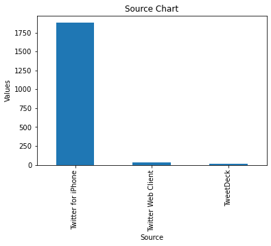

```python
mergedData2["source"].value_counts().plot( kind = 'bar')
plt.xlabel('Source')
plt.ylabel('Values')
plt.title('Source Chart')

plt.show()
```

many people tweeted from iphone

```python
#to check the breed with the highest retweet
mergedData2.sort_values(['retweet_count','breed'], ascending = False).head(5)
```

|  | tweet_id | timestamp | source | text | name | numerator | denominator | stages | retweet_count | favorite_count | jpg_url | img_num | breed | prediction |
| --- | --- | --- | --- | --- | --- | --- | --- | --- | --- | --- | --- | --- | --- | --- |
| 742 | 744234799360020481 | 2016-06-18 18:26:18+00:00 | Twitter for iPhone | Here's a doggo realizing you can stand in a pool. 13/10 enlightened af (vid by Tina Conrad) https://t.co/7wE9LTEXC4 | None | 13 | 10 | doggo | 79515 | 131075 | https://pbs.twimg.com/ext_tw_video_thumb/744234667679821824/pu/img/1GaWmtJtdqzZV7jy.jpg | 1 | Labrador_retriever | 0.825333 |
| 379 | 807106840509214720 | 2016-12-09 06:17:20+00:00 | Twitter for iPhone | This is Stephan. He just wants to help. 13/10 such a good boy https://t.co/DkBYaCAg2d | Stephan | 13 | 10 | NaN | 56625 | 107015 | https://pbs.twimg.com/ext_tw_video_thumb/807106774843039744/pu/img/8XZg1xW35Xp2J6JW.jpg | 1 | Chihuahua | 0.505370 |
| 775 | 739238157791694849 | 2016-06-04 23:31:25+00:00 | Twitter for iPhone | Here's a doggo blowing bubbles. It's downright legendary. 13/10 would watch on repeat forever (vid by Kent Duryee) https://t.co/YcXgHfp1EC | None | 13 | 10 | doggo | 52360 | 75163 | https://pbs.twimg.com/ext_tw_video_thumb/739238016737267712/pu/img/-tLpyiuIzD5zR1et.jpg | 1 | Eskimo_dog | 0.503372 |
| 292 | 822872901745569793 | 2017-01-21 18:26:02+00:00 | Twitter for iPhone | Here's a super supportive puppo participating in the Toronto #WomensMarch today. 13/10 https://t.co/nTz3FtorBc | None | 13 | 10 | puppo | 48265 | 132810 | https://pbs.twimg.com/media/C2tugXLXgAArJO4.jpg | 1 | Lakeland_terrier | 0.196015 |
| 56 | 879415818425184262 | 2017-06-26 19:07:24+00:00 | Twitter for iPhone | This is Duddles. He did an attempt. 13/10 someone help him (vid by Georgia Felici) https://t.co/UDT7ZkcTgY | Duddles | 13 | 10 | NaN | 45849 | 107956 | https://pbs.twimg.com/ext_tw_video_thumb/879415784908390401/pu/img/cX7XI1TnUsseGET5.jpg | 1 | English_springer | 0.383404 |

Labrador_retriever has the highest number of retweet

```python
#to check the dog with he favourite count
mergedData2.sort_values(['favorite_count','breed'], ascending = False).head(5)
```

|  | tweet_id | timestamp | source | text | name | numerator | denominator | stages | retweet_count | favorite_count | jpg_url | img_num | breed | prediction |
| --- | --- | --- | --- | --- | --- | --- | --- | --- | --- | --- | --- | --- | --- | --- |
| 292 | 822872901745569793 | 2017-01-21 18:26:02+00:00 | Twitter for iPhone | Here's a super supportive puppo participating in the Toronto #WomensMarch today. 13/10 https://t.co/nTz3FtorBc | None | 13 | 10 | puppo | 48265 | 132810 | https://pbs.twimg.com/media/C2tugXLXgAArJO4.jpg | 1 | Lakeland_terrier | 0.196015 |
| 742 | 744234799360020481 | 2016-06-18 18:26:18+00:00 | Twitter for iPhone | Here's a doggo realizing you can stand in a pool. 13/10 enlightened af (vid by Tina Conrad) https://t.co/7wE9LTEXC4 | None | 13 | 10 | doggo | 79515 | 131075 | https://pbs.twimg.com/ext_tw_video_thumb/744234667679821824/pu/img/1GaWmtJtdqzZV7jy.jpg | 1 | Labrador_retriever | 0.825333 |
| 56 | 879415818425184262 | 2017-06-26 19:07:24+00:00 | Twitter for iPhone | This is Duddles. He did an attempt. 13/10 someone help him (vid by Georgia Felici) https://t.co/UDT7ZkcTgY | Duddles | 13 | 10 | NaN | 45849 | 107956 | https://pbs.twimg.com/ext_tw_video_thumb/879415784908390401/pu/img/cX7XI1TnUsseGET5.jpg | 1 | English_springer | 0.383404 |
| 379 | 807106840509214720 | 2016-12-09 06:17:20+00:00 | Twitter for iPhone | This is Stephan. He just wants to help. 13/10 such a good boy https://t.co/DkBYaCAg2d | Stephan | 13 | 10 | NaN | 56625 | 107015 | https://pbs.twimg.com/ext_tw_video_thumb/807106774843039744/pu/img/8XZg1xW35Xp2J6JW.jpg | 1 | Chihuahua | 0.505370 |
| 103 | 866450705531457537 | 2017-05-22 00:28:40+00:00 | Twitter for iPhone | This is Jamesy. He gives a kiss to every other pupper he sees on his walk. 13/10 such passion, much tender https://t.co/wk7TfysWHr | Jamesy | 13 | 10 | pupper | 32883 | 106827 | https://pbs.twimg.com/media/DAZAUfBXcAAG_Nn.jpg | 2 | French_bulldog | 0.905334 |

Lakeland_terrier seemed to be the favourite of all

```python
#to check the dog with the favourite count and retweet_count
mergedData2.sort_values(['favorite_count', 'retweet_count', 'numerator', 'breed'], ascending = False).head(5)
```

|  | tweet_id | timestamp | source | text | name | numerator | denominator | stages | retweet_count | favorite_count | jpg_url | img_num | breed | prediction |
| --- | --- | --- | --- | --- | --- | --- | --- | --- | --- | --- | --- | --- | --- | --- |
| 292 | 822872901745569793 | 2017-01-21 18:26:02+00:00 | Twitter for iPhone | Here's a super supportive puppo participating in the Toronto #WomensMarch today. 13/10 https://t.co/nTz3FtorBc | None | 13 | 10 | puppo | 48265 | 132810 | https://pbs.twimg.com/media/C2tugXLXgAArJO4.jpg | 1 | Lakeland_terrier | 0.196015 |
| 742 | 744234799360020481 | 2016-06-18 18:26:18+00:00 | Twitter for iPhone | Here's a doggo realizing you can stand in a pool. 13/10 enlightened af (vid by Tina Conrad) https://t.co/7wE9LTEXC4 | None | 13 | 10 | doggo | 79515 | 131075 | https://pbs.twimg.com/ext_tw_video_thumb/744234667679821824/pu/img/1GaWmtJtdqzZV7jy.jpg | 1 | Labrador_retriever | 0.825333 |
| 56 | 879415818425184262 | 2017-06-26 19:07:24+00:00 | Twitter for iPhone | This is Duddles. He did an attempt. 13/10 someone help him (vid by Georgia Felici) https://t.co/UDT7ZkcTgY | Duddles | 13 | 10 | NaN | 45849 | 107956 | https://pbs.twimg.com/ext_tw_video_thumb/879415784908390401/pu/img/cX7XI1TnUsseGET5.jpg | 1 | English_springer | 0.383404 |
| 379 | 807106840509214720 | 2016-12-09 06:17:20+00:00 | Twitter for iPhone | This is Stephan. He just wants to help. 13/10 such a good boy https://t.co/DkBYaCAg2d | Stephan | 13 | 10 | NaN | 56625 | 107015 | https://pbs.twimg.com/ext_tw_video_thumb/807106774843039744/pu/img/8XZg1xW35Xp2J6JW.jpg | 1 | Chihuahua | 0.505370 |
| 103 | 866450705531457537 | 2017-05-22 00:28:40+00:00 | Twitter for iPhone | This is Jamesy. He gives a kiss to every other pupper he sees on his walk. 13/10 such passion, much tender https://t.co/wk7TfysWHr | Jamesy | 13 | 10 | pupper | 32883 | 106827 | https://pbs.twimg.com/media/DAZAUfBXcAAG_Nn.jpg | 2 | French_bulldog | 0.905334 |

it seems the Lakeland_terrier is the most popular of all

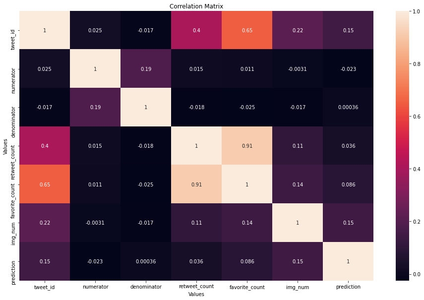

```python
#to check for corretaltion
from pandas import set_option
data = mergedData2
set_option('display.width', 100)

plt.figure(figsize=(16,10))

sns.heatmap(data.corr(), annot = True)
plt.xlabel('Values')
plt.ylabel('Values')
plt.title('Correlation Matrix')

plt.show()
```

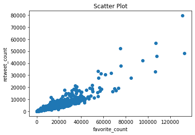

```python
x = mergedData2['favorite_count']
y = mergedData2['retweet_count']
plt.scatter(x, y)
plt.xlabel('favorite_count')
plt.ylabel('retweet_count')
plt.title('Scatter Plot')

plt.show()
```

retweet count and favorite count has a positive correlation, a dog with a high retweet count would have a high favorite count

## Conclusion

It is shown that the source of ratings for most people was from their iphones

Labrador_retriever has the highest number of retweet while Lakeland_terrier seemed to be the favourite of all

Also, a positive correLation was found between retweet count and favorite count, a dog with a high retweet count would have a high favorite count

Finally. it seems the Lakeland_terrier is the most popular of all!!